```python
'''
We will be using bokeh library in addition to matplotlib and seaborn
for visualisation of data throghout this notebook.
Below is the simple line chart using the bokeh for demostration purpose.

You can use the toolbox on the right side of chart to try out different functionalities
like zoom-in, zoom-out, reset to analyse specific part of the chart/graph.

Bokeh documentatin can be found here: https://docs.bokeh.org/en/latest/index.html
'''

from bokeh.application import Application
from bokeh.application.handlers import FunctionHandler
from bokeh.plotting import figure, output_file, show
from bokeh.io import output_notebook

#prepare some data
x = [1, 2, 3, 4, 5]
y = [6, 7, 2, 4, 5]

#output_notebook()
p = figure(title= "simple line example", x_axis_label='x', y_axis_label = 'y')
p.line(x, y, legend_label='Temp.', line_width =2)
show(p)
```

[interactive chart not shown]

# STEP 1 - Lookig at Raw Data

```python
import pandas as pd
import numpy as np
import json
import datetime as dt
import matplotlib.pyplot as plt
import seaborn as sns
from jupyterthemes import jtplot

plt.rcParams['figure.figsize'] = (20.0, 10.0)
%matplotlib inline

from sklearn.preprocessing import robust_scale, quantile_transform, scale
from matplotlib.figure import Figure
```

```python
# choose which theme to inherit plotting style from
# onedork | grade3 | oceans16 | chesterish | monokai | solarizedl | solarizedd
jtplot.style(theme='oceans16')

# set "context" (paper, notebook, talk, poster)
# scale font-size of ticklabels, legend, etc.
# remove spines from x and y axes and make grid dashed
jtplot.style(context='talk', fscale=1.4, spines=False, gridlines='--')

# turn on X- and Y-axis tick marks (default=False)
# turn off the axis grid lines (default=True)
# and set the default figure size
jtplot.style(ticks=True, grid=False, figsize=(6, 4.5))

# reset default matplotlib rcParams
#jtplot.reset()
```

```python
path = '../data/raw/'

# read in the json files
profile = pd.read_json(os.path.join(path, 'profile.json'), orient='records', lines=True)
transcript = pd.read_json(os.path.join(path, 'transcript.json'), orient='records', lines=True)
portfolio = pd.read_json(path + 'portfolio.json', orient='records', lines=True)
```

```python
portfolio.shape
```

```
(10, 6)
```

```python
portfolio.head()
```

|  | reward | channels | difficulty | duration | offer_type | id |
| --- | --- | --- | --- | --- | --- | --- |
| 0 | 10 | [email, mobile, social] | 10 | 7 | bogo | ae264e3637204a6fb9bb56bc8210ddfd |
| 1 | 10 | [web, email, mobile, social] | 10 | 5 | bogo | 4d5c57ea9a6940dd891ad53e9dbe8da0 |
| 2 | 0 | [web, email, mobile] | 0 | 4 | informational | 3f207df678b143eea3cee63160fa8bed |
| 3 | 5 | [web, email, mobile] | 5 | 7 | bogo | 9b98b8c7a33c4b65b9aebfe6a799e6d9 |
| 4 | 5 | [web, email] | 20 | 10 | discount | 0b1e1539f2cc45b7b9fa7c272da2e1d7 |

```python
portfolio.describe()
```

|  | reward | difficulty | duration |
| --- | --- | --- | --- |
| count | 10.000000 | 10.000000 | 10.000000 |
| mean | 4.200000 | 7.700000 | 6.500000 |
| std | 3.583915 | 5.831905 | 2.321398 |
| min | 0.000000 | 0.000000 | 3.000000 |
| 25% | 2.000000 | 5.000000 | 5.000000 |
| 50% | 4.000000 | 8.500000 | 7.000000 |
| 75% | 5.000000 | 10.000000 | 7.000000 |
| max | 10.000000 | 20.000000 | 10.000000 |

```python
portfolio['channels'].values.tolist()
```

```
[['email', 'mobile', 'social'],
 ['web', 'email', 'mobile', 'social'],
 ['web', 'email', 'mobile'],
 ['web', 'email', 'mobile'],
 ['web', 'email'],
 ['web', 'email', 'mobile', 'social'],
 ['web', 'email', 'mobile', 'social'],
 ['email', 'mobile', 'social'],
 ['web', 'email', 'mobile', 'social'],
 ['web', 'email', 'mobile']]
```

Looking at the 'channels' columns, it makes sense to disaggregate the each channel information into separated columns and encode it.

Let's write a function for it.

```python
def generic_one_hot_encoding(col, target_df):
    '''
    Transforms a given 'col' having multiple attributes to separate columns with 0/1 encoding values

    Inputs:
    col : input column
    example : channels -> [web, email, mobile, social]

    Return Value:

    Returns a 'target_df' with encoded columns names like [is_web, is_email, is_mobile, is_social]

    '''
    all_enconded_candidates = set()

    for enc_list in target_df[col].values.tolist():
        for cnd in enc_list:
            all_enconded_candidates.add(cnd)
    all_enconded_candidates = list(all_enconded_candidates)

    for cnd in all_enconded_candidates:
        target_df['is_' + cnd] = target_df[col].apply(
        lambda x: int(cnd in x))

    target_df = target_df.drop(col, axis =1)

    return target_df
```

```python
portfolio = generic_one_hot_encoding('channels', portfolio)
portfolio
```

|  | reward | difficulty | duration | offer_type | id | is_mobile | is_web | is_email | is_social |
| --- | --- | --- | --- | --- | --- | --- | --- | --- | --- |
| 0 | 10 | 10 | 7 | bogo | ae264e3637204a6fb9bb56bc8210ddfd | 1 | 0 | 1 | 1 |
| 1 | 10 | 10 | 5 | bogo | 4d5c57ea9a6940dd891ad53e9dbe8da0 | 1 | 1 | 1 | 1 |
| 2 | 0 | 0 | 4 | informational | 3f207df678b143eea3cee63160fa8bed | 1 | 1 | 1 | 0 |
| 3 | 5 | 5 | 7 | bogo | 9b98b8c7a33c4b65b9aebfe6a799e6d9 | 1 | 1 | 1 | 0 |
| 4 | 5 | 20 | 10 | discount | 0b1e1539f2cc45b7b9fa7c272da2e1d7 | 0 | 1 | 1 | 0 |
| 5 | 3 | 7 | 7 | discount | 2298d6c36e964ae4a3e7e9706d1fb8c2 | 1 | 1 | 1 | 1 |
| 6 | 2 | 10 | 10 | discount | fafdcd668e3743c1bb461111dcafc2a4 | 1 | 1 | 1 | 1 |
| 7 | 0 | 0 | 3 | informational | 5a8bc65990b245e5a138643cd4eb9837 | 1 | 0 | 1 | 1 |
| 8 | 5 | 5 | 5 | bogo | f19421c1d4aa40978ebb69ca19b0e20d | 1 | 1 | 1 | 1 |
| 9 | 2 | 10 | 7 | discount | 2906b810c7d4411798c6938adc9daaa5 | 1 | 1 | 1 | 0 |

*Observation*

- Each indvidual offer is unique even though some of offers belongs to same offer_type. I assume offers belonging to same offer_type more similar to each other than offer belonging to differet offer_type. Hence we should only onsider offer_type as influencing factor in determining the customer behavior
- To validate the influence of offers within same offer_type group, a separate A/B test should be conducted.

Let's create dummies for offer_type column and encode it and create a new dataframe

```python
# We will create dummies for the column offer_type and remove the original column

portfolio_new = portfolio.join(pd.get_dummies(portfolio.offer_type))
portfolio_new.drop(['offer_type'], axis =1 , inplace = True)
```

```python
portfolio_new.head(5)
```

|  | reward | difficulty | duration | id | is_mobile | is_web | is_email | is_social | bogo | discount | informational |
| --- | --- | --- | --- | --- | --- | --- | --- | --- | --- | --- | --- |
| 0 | 10 | 10 | 7 | ae264e3637204a6fb9bb56bc8210ddfd | 1 | 0 | 1 | 1 | 1 | 0 | 0 |
| 1 | 10 | 10 | 5 | 4d5c57ea9a6940dd891ad53e9dbe8da0 | 1 | 1 | 1 | 1 | 1 | 0 | 0 |
| 2 | 0 | 0 | 4 | 3f207df678b143eea3cee63160fa8bed | 1 | 1 | 1 | 0 | 0 | 0 | 1 |
| 3 | 5 | 5 | 7 | 9b98b8c7a33c4b65b9aebfe6a799e6d9 | 1 | 1 | 1 | 0 | 1 | 0 | 0 |
| 4 | 5 | 20 | 10 | 0b1e1539f2cc45b7b9fa7c272da2e1d7 | 0 | 1 | 1 | 0 | 0 | 1 | 0 |

It seems that we should simplify id values by only showing first 6 characters of it.

```python
#portfolio_new['id'] = portfolio_new.id.str[:6]
portfolio_new
```

[output not shown]

Let's re-order the column name to make it more appropriate (i.e. id columns should be first)

```python
#change column order

portfolio_new = portfolio_new[
    ['id', 'difficulty', 'reward',
     'duration','is_mobile', 'is_web',
     'is_social', 'is_email','bogo',
     'discount','informational']
    ]
```

```python
portfolio_new
```

|  | id | difficulty | reward | duration | is_mobile | is_web | is_social | is_email | bogo | discount | informational |
| --- | --- | --- | --- | --- | --- | --- | --- | --- | --- | --- | --- |
| 0 | ae264e3637204a6fb9bb56bc8210ddfd | 10 | 10 | 7 | 1 | 0 | 1 | 1 | 1 | 0 | 0 |
| 1 | 4d5c57ea9a6940dd891ad53e9dbe8da0 | 10 | 10 | 5 | 1 | 1 | 1 | 1 | 1 | 0 | 0 |
| 2 | 3f207df678b143eea3cee63160fa8bed | 0 | 0 | 4 | 1 | 1 | 0 | 1 | 0 | 0 | 1 |
| 3 | 9b98b8c7a33c4b65b9aebfe6a799e6d9 | 5 | 5 | 7 | 1 | 1 | 0 | 1 | 1 | 0 | 0 |
| 4 | 0b1e1539f2cc45b7b9fa7c272da2e1d7 | 20 | 5 | 10 | 0 | 1 | 0 | 1 | 0 | 1 | 0 |
| 5 | 2298d6c36e964ae4a3e7e9706d1fb8c2 | 7 | 3 | 7 | 1 | 1 | 1 | 1 | 0 | 1 | 0 |
| 6 | fafdcd668e3743c1bb461111dcafc2a4 | 10 | 2 | 10 | 1 | 1 | 1 | 1 | 0 | 1 | 0 |
| 7 | 5a8bc65990b245e5a138643cd4eb9837 | 0 | 0 | 3 | 1 | 0 | 1 | 1 | 0 | 0 | 1 |
| 8 | f19421c1d4aa40978ebb69ca19b0e20d | 5 | 5 | 5 | 1 | 1 | 1 | 1 | 1 | 0 | 0 |
| 9 | 2906b810c7d4411798c6938adc9daaa5 | 10 | 2 | 7 | 1 | 1 | 0 | 1 | 0 | 1 | 0 |

*Observation*

- Here each offer is always sent via email channel. Therefore this feature is only informative and may not add any value to the predictive power of any machine learning algorithm.

Before we move on to Profile dataset, let's briefly consider data scaling issues in Portfolia dataframe. We have 'difficulty', 'reward', 'duration' on different numberic scale and unit. We should try to rescale it with mean value around 0.

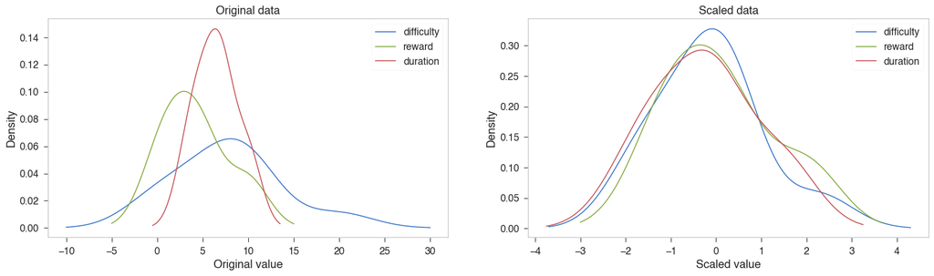

```python
figure, axis = plt.subplots(figsize=(20, 5), nrows=1, ncols=2)
numeric_columns = ['difficulty','reward','duration']

numeric_df = portfolio_new[numeric_columns]

numeric_df.plot.density(ax=axis[0])
axis[0].set_title('Original data')
axis[0].set_xlabel('Original value')

scaled_df = robust_scale(numeric_df)
scaled_df = pd.DataFrame(scaled_df, columns=numeric_df.columns, index=numeric_df.index)

scaled_df.plot.density(ax=axis[1])
axis[1].set_title('Scaled data')
axis[1].set_xlabel('Scaled value')
```

```python
profile
```

|  | gender | age | id | became_member_on | income |
| --- | --- | --- | --- | --- | --- |
| 0 | None | 118 | 68be06ca386d4c31939f3a4f0e3dd783 | 20170212 | NaN |
| 1 | F | 55 | 0610b486422d4921ae7d2bf64640c50b | 20170715 | 112000.0 |
| 2 | None | 118 | 38fe809add3b4fcf9315a9694bb96ff5 | 20180712 | NaN |
| 3 | F | 75 | 78afa995795e4d85b5d9ceeca43f5fef | 20170509 | 100000.0 |
| 4 | None | 118 | a03223e636434f42ac4c3df47e8bac43 | 20170804 | NaN |
| ... | ... | ... | ... | ... | ... |
| 16995 | F | 45 | 6d5f3a774f3d4714ab0c092238f3a1d7 | 20180604 | 54000.0 |
| 16996 | M | 61 | 2cb4f97358b841b9a9773a7aa05a9d77 | 20180713 | 72000.0 |
| 16997 | M | 49 | 01d26f638c274aa0b965d24cefe3183f | 20170126 | 73000.0 |
| 16998 | F | 83 | 9dc1421481194dcd9400aec7c9ae6366 | 20160307 | 50000.0 |
| 16999 | F | 62 | e4052622e5ba45a8b96b59aba68cf068 | 20170722 | 82000.0 |

17000 rows × 5 columns

```python
profile.describe()
```

|  | age | became_member_on | income |
| --- | --- | --- | --- |
| count | 17000.000000 | 1.700000e+04 | 14825.000000 |
| mean | 62.531412 | 2.016703e+07 | 65404.991568 |
| std | 26.738580 | 1.167750e+04 | 21598.299410 |
| min | 18.000000 | 2.013073e+07 | 30000.000000 |
| 25% | 45.000000 | 2.016053e+07 | 49000.000000 |
| 50% | 58.000000 | 2.017080e+07 | 64000.000000 |
| 75% | 73.000000 | 2.017123e+07 | 80000.000000 |
| max | 118.000000 | 2.018073e+07 | 120000.000000 |

```python
set(profile.gender.values.tolist())
```

```
{'F', 'M', None, 'O'}
```

```python
profile[profile['age'] == 118]
```

|  | gender | age | id | became_member_on | income |
| --- | --- | --- | --- | --- | --- |
| 0 | None | 118 | 68be06ca386d4c31939f3a4f0e3dd783 | 20170212 | NaN |
| 2 | None | 118 | 38fe809add3b4fcf9315a9694bb96ff5 | 20180712 | NaN |
| 4 | None | 118 | a03223e636434f42ac4c3df47e8bac43 | 20170804 | NaN |
| 6 | None | 118 | 8ec6ce2a7e7949b1bf142def7d0e0586 | 20170925 | NaN |
| 7 | None | 118 | 68617ca6246f4fbc85e91a2a49552598 | 20171002 | NaN |
| ... | ... | ... | ... | ... | ... |
| 16980 | None | 118 | 5c686d09ca4d475a8f750f2ba07e0440 | 20160901 | NaN |
| 16982 | None | 118 | d9ca82f550ac4ee58b6299cf1e5c824a | 20160415 | NaN |
| 16989 | None | 118 | ca45ee1883624304bac1e4c8a114f045 | 20180305 | NaN |
| 16991 | None | 118 | a9a20fa8b5504360beb4e7c8712f8306 | 20160116 | NaN |
| 16994 | None | 118 | c02b10e8752c4d8e9b73f918558531f7 | 20151211 | NaN |

2175 rows × 5 columns

It is obvious that age value 118 is placeholder for misisng value. The above analysis suggests that 2175 entries are missing for gender, age and income columns togather We should consider removing all rows if we consider any demographic data in order to find insights Currently, let's keep it as-is

```python
profile['gender'].value_counts()
```

```
M    8484
F    6129
O     212
Name: gender, dtype: int64
```

```python
profile.isnull().sum()
```

```
gender              2175
age                    0
id                     0
became_member_on       0
income              2175
dtype: int64
```

```python
profile.became_member_on
```

```
0        20170212
1        20170715
2        20180712
3        20170509
4        20170804
           ...
16995    20180604
16996    20180713
16997    20170126
16998    20160307
16999    20170722
Name: became_member_on, Length: 17000, dtype: int64
```

```python
#change data format
profile.became_member_on = pd.to_datetime(profile.became_member_on, format='%Y%m%d', errors='coerce')

profile.head()
```

|  | gender | age | id | became_member_on | income |
| --- | --- | --- | --- | --- | --- |
| 0 | None | 118 | 68be06ca386d4c31939f3a4f0e3dd783 | 2017-02-12 | NaN |
| 1 | F | 55 | 0610b486422d4921ae7d2bf64640c50b | 2017-07-15 | 112000.0 |
| 2 | None | 118 | 38fe809add3b4fcf9315a9694bb96ff5 | 2018-07-12 | NaN |
| 3 | F | 75 | 78afa995795e4d85b5d9ceeca43f5fef | 2017-05-09 | 100000.0 |
| 4 | None | 118 | a03223e636434f42ac4c3df47e8bac43 | 2017-08-04 | NaN |

```python
profile.became_member_on.max()
```

```
Timestamp('2018-07-26 00:00:00')
```

```python
profile['member_since_x_days'] = (
pd.to_datetime('today') - profile.became_member_on)
profile['member_since_x_days'] = profile['member_since_x_days'].dt.days
```

```python
profile
```

|  | gender | age | id | became_member_on | income | member_since_x_days |
| --- | --- | --- | --- | --- | --- | --- |
| 0 | None | 118 | 68be06ca386d4c31939f3a4f0e3dd783 | 2017-02-12 | NaN | 1163 |
| 1 | F | 55 | 0610b486422d4921ae7d2bf64640c50b | 2017-07-15 | 112000.0 | 1010 |
| 2 | None | 118 | 38fe809add3b4fcf9315a9694bb96ff5 | 2018-07-12 | NaN | 648 |
| 3 | F | 75 | 78afa995795e4d85b5d9ceeca43f5fef | 2017-05-09 | 100000.0 | 1077 |
| 4 | None | 118 | a03223e636434f42ac4c3df47e8bac43 | 2017-08-04 | NaN | 990 |
| ... | ... | ... | ... | ... | ... | ... |
| 16995 | F | 45 | 6d5f3a774f3d4714ab0c092238f3a1d7 | 2018-06-04 | 54000.0 | 686 |
| 16996 | M | 61 | 2cb4f97358b841b9a9773a7aa05a9d77 | 2018-07-13 | 72000.0 | 647 |
| 16997 | M | 49 | 01d26f638c274aa0b965d24cefe3183f | 2017-01-26 | 73000.0 | 1180 |
| 16998 | F | 83 | 9dc1421481194dcd9400aec7c9ae6366 | 2016-03-07 | 50000.0 | 1505 |
| 16999 | F | 62 | e4052622e5ba45a8b96b59aba68cf068 | 2017-07-22 | 82000.0 | 1003 |

17000 rows × 6 columns

```python
profile.head()
```

[output not shown]

Let's create some visualisations to analyze the demographic data

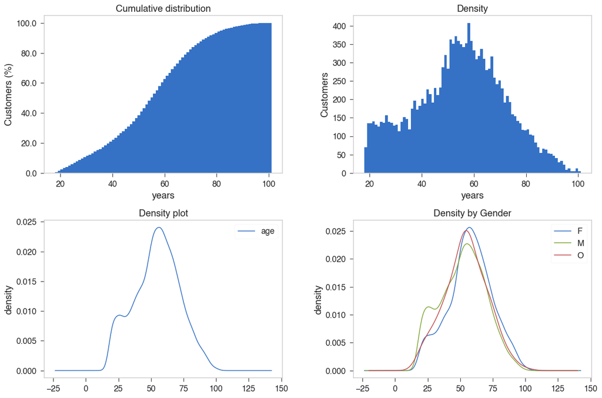

```python
age_missing = profile.age == 118

## Select registers with valid age
age_df = pd.DataFrame(profile.age[~age_missing])

## Generate the registers' description
description_pdstyle = \
    pd.DataFrame(age_df.describe()).style \
    .set_caption('Ages description') \
    .set_table_attributes('style="display:inline;' \
                          'vertical-align:top"')
## Generate box and violin plots
fig1 = Figure(figsize=(10,4))
axs = fig1.subplots(nrows=1, ncols=2)
axs = axs.flatten()
axs[0].set_title('Box Plot')
age_df.plot.box(ax=axs[0])
axs[1].violinplot(age_df.values)
axs[1].set_title('Violin Plot')

## Generate histograms
bins = 84
fig2, axs = plt.subplots(nrows=2, ncols=2, figsize=(15, 10))
axs = axs.flatten()

# Cumulative distribution
age_df.hist(bins=bins, ax=axs[0], cumulative=True, density=True)
axs[0].set_title('Cumulative distribution')
axs[0].set_ylabel('Customers (%)')
axs[0].set_yticklabels((axs[0].get_yticks()*100).round(0))
axs[0].set_xscale('linear')
axs[0].set_xlabel('years')
axs[0].grid(False)

# Histogram
age_df.hist(bins=bins, ax=axs[1])
axs[1].set_title('Density')
axs[1].set_ylabel('Customers')
axs[1].set_xscale('linear')
axs[1].set_xlabel('years')
axs[1].grid(False)

# density
age_df.plot.density(ax=axs[2])
axs[2].legend()
axs[2].set_title('Density plot')
axs[2].set_ylabel('density')
axs[2].grid(False)

age_gender_df = profile[~age_missing].groupby('gender').age
age_gender_df.plot.density(ax=axs[3])
axs[3].set_title('Density by Gender')
axs[3].set_ylabel('density')
axs[3].legend()
axs[3].grid(False)


plt.show()
```

*Observation*

- For each gender, the age distribution is roughly similar and picks at around age of 60. This means that most customer are middle aged with some younger male customer at around age 25.

```python
import numpy as np
import scipy.special

from bokeh.layouts import gridplot
from bokeh.plotting import figure, output_file, show

def make_plot(title, hist, edges, x, pdf, cdf):
    p = figure(title=title, tools='', background_fill_color="#fafafa")
    p.quad(top=hist, bottom=0, left=edges[:-1], right=edges[1:],
           fill_color="navy", line_color="white", alpha=0.5)

    p.y_range.start = 0
    p.y_range.end = 0.03
    p.legend.location = "center_right"
    p.legend.background_fill_color = "#fefefe"
    p.xaxis.axis_label = 'x'
    p.yaxis.axis_label = 'Pr(x)'
    p.grid.grid_line_color="white"
    return p

measured = np.asarray(age_df.age.tolist(), dtype=np.float32)
hist, edges = np.histogram(measured, density=True, bins=84)
x = measured

p1 = make_plot("Age Distribution", hist, edges, x, None, None)
show(p1)
```

[interactive chart not shown]

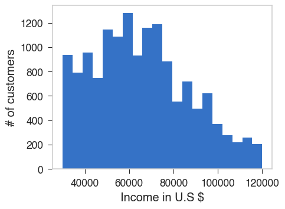

```python
axs = profile.income.hist(bins = 20)
axs.grid(False)
axs.set_ylabel('# of customers')
axs.set_xlabel('Income in U.S $')
```

*Observation*

- Surprisingly, there are many customers who falls into relatively lower income group and very few customers who falls into relatively high income groups. This could be due to the fact that younger customers may be earning less.

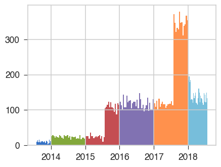

```python
axs = profile.became_member_on.groupby(profile.became_member_on.dt.year).hist(bins=30)
```

*Observation*

- The above chart shows that there is a steady increse in the number of customer who started using starbucks app. However, there is steep fall at the end of 2017. This could also be due to sampling bias (more customers have been sampled from mid 2017 duration) to prepare the dataset

```python
profile
```

[output not shown]

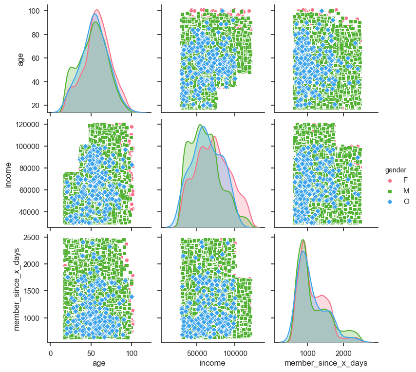

```python
sns.set(style= "ticks", color_codes=True)
normal_pair_plot = sns.pairplot(profile[['age',
                      'income',
                      'gender',
                      'member_since_x_days']].dropna(),
             hue='gender',
             palette="husl",
             markers=["o", "s", "D"])

normal_pair_plot
```

[figure not shown]

```python
#Use kernal density eistomators for univariate plots
sns.set(style= "ticks", color_codes=True)
kde_pair_plot = sns.pairplot(profile[['age',
                      'income',
                      'gender',
                      'member_since_x_days']].dropna(),
             hue='gender',
             palette="Paired",
             markers=["o", "s", "D"], kind= "kde")
kde_pair_plot
```

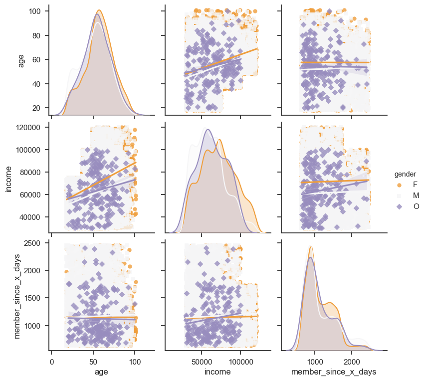

```python
#Fit linear regression models to the scatter plots:
sns.set(style= "ticks", color_codes=True)
reg_pair_plot = sns.pairplot(profile[['age',
                      'income',
                      'gender',
                      'member_since_x_days']].dropna(),
             hue='gender',
             palette="PuOr",
             markers=["o", "s", "D"], kind= "reg")
reg_pair_plot
```

*Observation*

The above set of chart leads to some interesting observations

- There exist no customer in the age group [20, 30] having income greater thean 80K.
- Similarly there exists not customer in the age group [40, 50] having income greater than 100K.
- All the customer who became member more than 2000 days ago has income less than 100K.

```python
#https://docs.bokeh.org/en/latest/docs/gallery/pie_chart.html?highlight=pie%20chart

def draw_pie_chart(data_dict, output_file_name):

    from math import pi
    import pandas as pd
    from bokeh.io import output_file, show
    from bokeh.palettes import Category20c
    from bokeh.plotting import figure
    from bokeh.transform import cumsum

    output_file(output_file_name + ".html")
    x = data_dict
    data = pd.Series(x).reset_index(name='value').rename(columns={'index':'event'})
    data['angle'] = data['value']/data['value'].sum() * 2*pi
    data['color'] = Category20c[len(x)]

    p = figure(plot_height=350, title="Pie Chart", toolbar_location=None,
           tools="hover", tooltips="@event: @value", x_range=(-0.5, 1.0))

    p.wedge(x=0, y=1, radius=0.4,
        start_angle=cumsum('angle', include_zero=True), end_angle=cumsum('angle'),
        line_color="white", fill_color='color', legend_field='event', source=data)

    p.axis.axis_label=None
    p.axis.visible=False
    p.grid.grid_line_color = None

    show(p)
```

```python
data_dict_1 = {
    'Transction': 138953,
    'Offer received': 76277,
    'Offer viewed': 57725,
    'Offer completed': 33579
}

draw_pie_chart(data_dict_1, 'pie_1')

data_dict_2 = {
    'Offer received': 76277,
    'Offer viewed': 57725,
    'Offer completed': 33579
}

draw_pie_chart(data_dict_2, 'pie_2')
```

[interactive chart not shown]

```python
t_p_set =set(transcript['person'].values.tolist())

len(t_p_set)
```

```
17000
```

```python
p_set = set(profile['id'].values.tolist())

len(p_set)
```

```
17000
```

```python
print(t_p_set - p_set)
```

```
set()
```

*Observation*  
The above analysis suggests that all the persons in transaction is found in the profile i.e. for each transaction, there is person with known demographics

```python
transcript
```

|  | person | event | value | time |
| --- | --- | --- | --- | --- |
| 0 | 78afa995795e4d85b5d9ceeca43f5fef | offer received | {'offer id': '9b98b8c7a33c4b65b9aebfe6a799e6d9'} | 0 |
| 1 | a03223e636434f42ac4c3df47e8bac43 | offer received | {'offer id': '0b1e1539f2cc45b7b9fa7c272da2e1d7'} | 0 |
| 2 | e2127556f4f64592b11af22de27a7932 | offer received | {'offer id': '2906b810c7d4411798c6938adc9daaa5'} | 0 |
| 3 | 8ec6ce2a7e7949b1bf142def7d0e0586 | offer received | {'offer id': 'fafdcd668e3743c1bb461111dcafc2a4'} | 0 |
| 4 | 68617ca6246f4fbc85e91a2a49552598 | offer received | {'offer id': '4d5c57ea9a6940dd891ad53e9dbe8da0'} | 0 |
| ... | ... | ... | ... | ... |
| 306529 | b3a1272bc9904337b331bf348c3e8c17 | transaction | {'amount': 1.5899999999999999} | 714 |
| 306530 | 68213b08d99a4ae1b0dcb72aebd9aa35 | transaction | {'amount': 9.53} | 714 |
| 306531 | a00058cf10334a308c68e7631c529907 | transaction | {'amount': 3.61} | 714 |
| 306532 | 76ddbd6576844afe811f1a3c0fbb5bec | transaction | {'amount': 3.5300000000000002} | 714 |
| 306533 | c02b10e8752c4d8e9b73f918558531f7 | transaction | {'amount': 4.05} | 714 |

306534 rows × 4 columns

*Observation*

The initial looks at transcript dataset suggests that value column is encoded as dictionary. If event is related to offers, then values column encode offer id and in case of transaction event, it encode the amount of transcation.

Therefore, it makes sense to decode the value column into separate columns to better understand the relatationship between event status and corresponding effect on amount spent by the customers.

```python
#Let's transform value column into separate columns

def transform_value(transaction):
    '''transform/unpivot the value column and return new transcript dataframe'''

    values = pd.DataFrame(transaction.value.tolist())
    values.offer_id.update(values['offer id'])
    values = values.drop('offer id', axis=1)

    return transaction.join(values).drop('value', axis=1)
```

```python
transcript = transform_value(transcript)
transcript
```

|  | person | event | time | amount | offer_id | reward |
| --- | --- | --- | --- | --- | --- | --- |
| 0 | 78afa995795e4d85b5d9ceeca43f5fef | offer received | 0 | NaN | 9b98b8c7a33c4b65b9aebfe6a799e6d9 | NaN |
| 1 | a03223e636434f42ac4c3df47e8bac43 | offer received | 0 | NaN | 0b1e1539f2cc45b7b9fa7c272da2e1d7 | NaN |
| 2 | e2127556f4f64592b11af22de27a7932 | offer received | 0 | NaN | 2906b810c7d4411798c6938adc9daaa5 | NaN |
| 3 | 8ec6ce2a7e7949b1bf142def7d0e0586 | offer received | 0 | NaN | fafdcd668e3743c1bb461111dcafc2a4 | NaN |
| 4 | 68617ca6246f4fbc85e91a2a49552598 | offer received | 0 | NaN | 4d5c57ea9a6940dd891ad53e9dbe8da0 | NaN |
| ... | ... | ... | ... | ... | ... | ... |
| 306529 | b3a1272bc9904337b331bf348c3e8c17 | transaction | 714 | 1.59 | NaN | NaN |
| 306530 | 68213b08d99a4ae1b0dcb72aebd9aa35 | transaction | 714 | 9.53 | NaN | NaN |
| 306531 | a00058cf10334a308c68e7631c529907 | transaction | 714 | 3.61 | NaN | NaN |
| 306532 | 76ddbd6576844afe811f1a3c0fbb5bec | transaction | 714 | 3.53 | NaN | NaN |
| 306533 | c02b10e8752c4d8e9b73f918558531f7 | transaction | 714 | 4.05 | NaN | NaN |

306534 rows × 6 columns

```python
transcript.isna().sum()
```

[output not shown]

*Observation*

First of all, we should find out the total count of the completed offers after being viewed for each customers. The current data includes 'offers completed' by customers, knowingly or unknowingly. The customers who have unknowingly completed offers should not be sent out a further offers. This target group represents a profitable customers for the company.

In order to answer above question,

Let's find out customer who have received the offers but has not viewed it. We will first combine our transcript dataset with the customer demographics (profiles) first and then identify those customers.

It could also be the case a single customer may has received a multiple offer but he may not viewed all of them but may have completed them anyway unknowingly.

```python
#transcript['offer_id'] = transcript.offer_id.str[:6]
```

```python
portfolio_new
```

[output not shown]

```python
def join_data(transcript, profile, portfolio, static=True):

    """
    Joins the three sources of data in one dataframe.
    Args:
        transcript(pandas dataframe): Contains the events (part of the raw
            data)
        profile(pandas dataframe): Contains the customer's profiles (part of
            the raw data)
        portfolio(pandas dataframe): Contains the offers (part of the raw data)
        static(boolean): If True, remove the customer and offer ids. Otherwise
            keep them for a possible time-dependent analysis.
    Returns:
        merged_df(pd.DataFrame): The joined dataframe.
    """

    merged_df = transcript.merge(profile, left_on='person', right_on='id',
                                 how='left').drop('id', axis=1)
    merged_df = merged_df.merge(portfolio,
        left_on='offer_id', right_on='id', how='left').drop('id', axis=1)
    if static:
        merged_df = merged_df.drop(['person', 'offer_id'], axis=1)

    return merged_df
```

```python
merged_df = join_data(transcript, profile, portfolio_new, static=False)
```

```python
merged_df = merged_df.rename(columns={'reward_x' : 'rewards_t' , 'reward_y' : 'rewards_p'})
```

```python
display(pd.DataFrame().append([
    merged_df.query('event=="offer received"').head(),
    merged_df.query('event=="offer viewed"').head(),
    merged_df.query('event=="transaction"').head(),
    merged_df.query('event=="offer completed"').head(),
    merged_df.query('person=="78afa995795e4d85b5d9ceeca43f5fef"').head(),
    merged_df.query('person=="02c083884c7d45b39cc68e1314fec56c"').head()]))
```

|  | person | event | time | amount | offer_id | rewards_t | gender | age | became_member_on | income | difficulty | rewards_p | duration | is_mobile | is_web | is_social | is_email | bogo | discount | informational |
| --- | --- | --- | --- | --- | --- | --- | --- | --- | --- | --- | --- | --- | --- | --- | --- | --- | --- | --- | --- | --- |
| 0 | 78afa995795e4d85b5d9ceeca43f5fef | offer received | 0 | NaN | 9b98b8c7a33c4b65b9aebfe6a799e6d9 | NaN | F | 75 | 20170509 | 100000.0 | 5.0 | 5.0 | 7.0 | 1.0 | 1.0 | 0.0 | 1.0 | 1.0 | 0.0 | 0.0 |
| 1 | a03223e636434f42ac4c3df47e8bac43 | offer received | 0 | NaN | 0b1e1539f2cc45b7b9fa7c272da2e1d7 | NaN | None | 118 | 20170804 | NaN | 20.0 | 5.0 | 10.0 | 0.0 | 1.0 | 0.0 | 1.0 | 0.0 | 1.0 | 0.0 |
| 2 | e2127556f4f64592b11af22de27a7932 | offer received | 0 | NaN | 2906b810c7d4411798c6938adc9daaa5 | NaN | M | 68 | 20180426 | 70000.0 | 10.0 | 2.0 | 7.0 | 1.0 | 1.0 | 0.0 | 1.0 | 0.0 | 1.0 | 0.0 |
| 3 | 8ec6ce2a7e7949b1bf142def7d0e0586 | offer received | 0 | NaN | fafdcd668e3743c1bb461111dcafc2a4 | NaN | None | 118 | 20170925 | NaN | 10.0 | 2.0 | 10.0 | 1.0 | 1.0 | 1.0 | 1.0 | 0.0 | 1.0 | 0.0 |
| 4 | 68617ca6246f4fbc85e91a2a49552598 | offer received | 0 | NaN | 4d5c57ea9a6940dd891ad53e9dbe8da0 | NaN | None | 118 | 20171002 | NaN | 10.0 | 10.0 | 5.0 | 1.0 | 1.0 | 1.0 | 1.0 | 1.0 | 0.0 | 0.0 |
| 12650 | 389bc3fa690240e798340f5a15918d5c | offer viewed | 0 | NaN | f19421c1d4aa40978ebb69ca19b0e20d | NaN | M | 65 | 20180209 | 53000.0 | 5.0 | 5.0 | 5.0 | 1.0 | 1.0 | 1.0 | 1.0 | 1.0 | 0.0 | 0.0 |
| 12651 | d1ede868e29245ea91818a903fec04c6 | offer viewed | 0 | NaN | 5a8bc65990b245e5a138643cd4eb9837 | NaN | O | 53 | 20170916 | 52000.0 | 0.0 | 0.0 | 3.0 | 1.0 | 0.0 | 1.0 | 1.0 | 0.0 | 0.0 | 1.0 |
| 12652 | 102e9454054946fda62242d2e176fdce | offer viewed | 0 | NaN | 4d5c57ea9a6940dd891ad53e9dbe8da0 | NaN | F | 69 | 20160814 | 57000.0 | 10.0 | 10.0 | 5.0 | 1.0 | 1.0 | 1.0 | 1.0 | 1.0 | 0.0 | 0.0 |
| 12653 | 02c083884c7d45b39cc68e1314fec56c | offer viewed | 0 | NaN | ae264e3637204a6fb9bb56bc8210ddfd | NaN | F | 20 | 20160711 | 30000.0 | 10.0 | 10.0 | 7.0 | 1.0 | 0.0 | 1.0 | 1.0 | 1.0 | 0.0 | 0.0 |
| 12655 | be8a5d1981a2458d90b255ddc7e0d174 | offer viewed | 0 | NaN | 5a8bc65990b245e5a138643cd4eb9837 | NaN | M | 39 | 20140527 | 51000.0 | 0.0 | 0.0 | 3.0 | 1.0 | 0.0 | 1.0 | 1.0 | 0.0 | 0.0 | 1.0 |
| 12654 | 02c083884c7d45b39cc68e1314fec56c | transaction | 0 | 0.83 | NaN | NaN | F | 20 | 20160711 | 30000.0 | NaN | NaN | NaN | NaN | NaN | NaN | NaN | NaN | NaN | NaN |
| 12657 | 9fa9ae8f57894cc9a3b8a9bbe0fc1b2f | transaction | 0 | 34.56 | NaN | NaN | M | 42 | 20160117 | 96000.0 | NaN | NaN | NaN | NaN | NaN | NaN | NaN | NaN | NaN | NaN |
| 12659 | 54890f68699049c2a04d415abc25e717 | transaction | 0 | 13.23 | NaN | NaN | M | 36 | 20171228 | 56000.0 | NaN | NaN | NaN | NaN | NaN | NaN | NaN | NaN | NaN | NaN |
| 12670 | b2f1cd155b864803ad8334cdf13c4bd2 | transaction | 0 | 19.51 | NaN | NaN | F | 55 | 20171016 | 94000.0 | NaN | NaN | NaN | NaN | NaN | NaN | NaN | NaN | NaN | NaN |
| 12671 | fe97aa22dd3e48c8b143116a8403dd52 | transaction | 0 | 18.97 | NaN | NaN | F | 39 | 20171217 | 67000.0 | NaN | NaN | NaN | NaN | NaN | NaN | NaN | NaN | NaN | NaN |
| 12658 | 9fa9ae8f57894cc9a3b8a9bbe0fc1b2f | offer completed | 0 | NaN | 2906b810c7d4411798c6938adc9daaa5 | 2.0 | M | 42 | 20160117 | 96000.0 | 10.0 | 2.0 | 7.0 | 1.0 | 1.0 | 0.0 | 1.0 | 0.0 | 1.0 | 0.0 |
| 12672 | fe97aa22dd3e48c8b143116a8403dd52 | offer completed | 0 | NaN | fafdcd668e3743c1bb461111dcafc2a4 | 2.0 | F | 39 | 20171217 | 67000.0 | 10.0 | 2.0 | 10.0 | 1.0 | 1.0 | 1.0 | 1.0 | 0.0 | 1.0 | 0.0 |
| 12679 | 629fc02d56414d91bca360decdfa9288 | offer completed | 0 | NaN | 9b98b8c7a33c4b65b9aebfe6a799e6d9 | 5.0 | M | 52 | 20180605 | 72000.0 | 5.0 | 5.0 | 7.0 | 1.0 | 1.0 | 0.0 | 1.0 | 1.0 | 0.0 | 0.0 |
| 12692 | 676506bad68e4161b9bbaffeb039626b | offer completed | 0 | NaN | ae264e3637204a6fb9bb56bc8210ddfd | 10.0 | M | 37 | 20170515 | 92000.0 | 10.0 | 10.0 | 7.0 | 1.0 | 0.0 | 1.0 | 1.0 | 1.0 | 0.0 | 0.0 |
| 12697 | 8f7dd3b2afe14c078eb4f6e6fe4ba97d | offer completed | 0 | NaN | 4d5c57ea9a6940dd891ad53e9dbe8da0 | 10.0 | M | 48 | 20150903 | 62000.0 | 10.0 | 10.0 | 5.0 | 1.0 | 1.0 | 1.0 | 1.0 | 1.0 | 0.0 | 0.0 |
| 0 | 78afa995795e4d85b5d9ceeca43f5fef | offer received | 0 | NaN | 9b98b8c7a33c4b65b9aebfe6a799e6d9 | NaN | F | 75 | 20170509 | 100000.0 | 5.0 | 5.0 | 7.0 | 1.0 | 1.0 | 0.0 | 1.0 | 1.0 | 0.0 | 0.0 |
| 15561 | 78afa995795e4d85b5d9ceeca43f5fef | offer viewed | 6 | NaN | 9b98b8c7a33c4b65b9aebfe6a799e6d9 | NaN | F | 75 | 20170509 | 100000.0 | 5.0 | 5.0 | 7.0 | 1.0 | 1.0 | 0.0 | 1.0 | 1.0 | 0.0 | 0.0 |
| 47582 | 78afa995795e4d85b5d9ceeca43f5fef | transaction | 132 | 19.89 | NaN | NaN | F | 75 | 20170509 | 100000.0 | NaN | NaN | NaN | NaN | NaN | NaN | NaN | NaN | NaN | NaN |
| 47583 | 78afa995795e4d85b5d9ceeca43f5fef | offer completed | 132 | NaN | 9b98b8c7a33c4b65b9aebfe6a799e6d9 | 5.0 | F | 75 | 20170509 | 100000.0 | 5.0 | 5.0 | 7.0 | 1.0 | 1.0 | 0.0 | 1.0 | 1.0 | 0.0 | 0.0 |
| 49502 | 78afa995795e4d85b5d9ceeca43f5fef | transaction | 144 | 17.78 | NaN | NaN | F | 75 | 20170509 | 100000.0 | NaN | NaN | NaN | NaN | NaN | NaN | NaN | NaN | NaN | NaN |
| 27 | 02c083884c7d45b39cc68e1314fec56c | offer received | 0 | NaN | ae264e3637204a6fb9bb56bc8210ddfd | NaN | F | 20 | 20160711 | 30000.0 | 10.0 | 10.0 | 7.0 | 1.0 | 0.0 | 1.0 | 1.0 | 1.0 | 0.0 | 0.0 |
| 12653 | 02c083884c7d45b39cc68e1314fec56c | offer viewed | 0 | NaN | ae264e3637204a6fb9bb56bc8210ddfd | NaN | F | 20 | 20160711 | 30000.0 | 10.0 | 10.0 | 7.0 | 1.0 | 0.0 | 1.0 | 1.0 | 1.0 | 0.0 | 0.0 |
| 12654 | 02c083884c7d45b39cc68e1314fec56c | transaction | 0 | 0.83 | NaN | NaN | F | 20 | 20160711 | 30000.0 | NaN | NaN | NaN | NaN | NaN | NaN | NaN | NaN | NaN | NaN |
| 15565 | 02c083884c7d45b39cc68e1314fec56c | transaction | 6 | 1.44 | NaN | NaN | F | 20 | 20160711 | 30000.0 | NaN | NaN | NaN | NaN | NaN | NaN | NaN | NaN | NaN | NaN |
| 18071 | 02c083884c7d45b39cc68e1314fec56c | transaction | 12 | 4.56 | NaN | NaN | F | 20 | 20160711 | 30000.0 | NaN | NaN | NaN | NaN | NaN | NaN | NaN | NaN | NaN | NaN |

*Observation*

- When offer is completed, there is an entry made into 'rewards_t' which is equal to the 'rewards_p' for the offer completed
- There is a sequence of time starting with 0 when offer received and ending with time stamp in hour when offer is completed for each customer for each corresponding offer_id.
- When customer makes transaction which is greater than the offer reward values within offer duration (duration column, expressed in days), offer is completed immediately (same timestamp as transaction time stamp, see records 47582, 47583) and corresponding rewards is given to customer.
- Customer may received two different offers at the same timestamp and may completed two offers at the same time stamp if he/she made transaction which exceeds the rewards of both offer within offer validity.

This makes the extraction of time and offer relation for each customer challenging

Let's examine each value of events separately.

```python
offer_received_events = pd.DataFrame().append([
    merged_df[['person', 'event', 'time', 'offer_id', 'amount', 'duration','rewards_t', 'rewards_p']]
    .query('event=="offer received"')])

offer_received_events
```

|  | person | event | time | offer_id | amount | duration | rewards_t | rewards_p |
| --- | --- | --- | --- | --- | --- | --- | --- | --- |
| 0 | 78afa995795e4d85b5d9ceeca43f5fef | offer received | 0 | 9b98b8c7a33c4b65b9aebfe6a799e6d9 | NaN | 7.0 | NaN | 5.0 |
| 1 | a03223e636434f42ac4c3df47e8bac43 | offer received | 0 | 0b1e1539f2cc45b7b9fa7c272da2e1d7 | NaN | 10.0 | NaN | 5.0 |
| 2 | e2127556f4f64592b11af22de27a7932 | offer received | 0 | 2906b810c7d4411798c6938adc9daaa5 | NaN | 7.0 | NaN | 2.0 |
| 3 | 8ec6ce2a7e7949b1bf142def7d0e0586 | offer received | 0 | fafdcd668e3743c1bb461111dcafc2a4 | NaN | 10.0 | NaN | 2.0 |
| 4 | 68617ca6246f4fbc85e91a2a49552598 | offer received | 0 | 4d5c57ea9a6940dd891ad53e9dbe8da0 | NaN | 5.0 | NaN | 10.0 |
| ... | ... | ... | ... | ... | ... | ... | ... | ... |
| 257882 | d087c473b4d247ccb0abfef59ba12b0e | offer received | 576 | ae264e3637204a6fb9bb56bc8210ddfd | NaN | 7.0 | NaN | 10.0 |
| 257883 | cb23b66c56f64b109d673d5e56574529 | offer received | 576 | 2906b810c7d4411798c6938adc9daaa5 | NaN | 7.0 | NaN | 2.0 |
| 257884 | 6d5f3a774f3d4714ab0c092238f3a1d7 | offer received | 576 | 2298d6c36e964ae4a3e7e9706d1fb8c2 | NaN | 7.0 | NaN | 3.0 |
| 257885 | 9dc1421481194dcd9400aec7c9ae6366 | offer received | 576 | ae264e3637204a6fb9bb56bc8210ddfd | NaN | 7.0 | NaN | 10.0 |
| 257886 | e4052622e5ba45a8b96b59aba68cf068 | offer received | 576 | 3f207df678b143eea3cee63160fa8bed | NaN | 4.0 | NaN | 0.0 |

76277 rows × 8 columns

```python
offer_received_events.time.max()/24
```

```
24.0
```

```python
offer_received_events.time.describe()
```

```
count    76277.000000
mean       332.579519
std        196.489548
min          0.000000
25%        168.000000
50%        408.000000
75%        504.000000
max        576.000000
Name: time, dtype: float64
```

```python
offer_received_events.time.value_counts().sort_values(ascending=True)
```

```
0      12650
168    12669
504    12704
336    12711
576    12765
408    12778
Name: time, dtype: int64
```

```python
s_sent = offer_received_events.time.value_counts().sort_index(ascending=True)
```

```python
offer_sent_time_in_hours = offer_received_events.time.value_counts().sort_index(ascending=True).index.tolist()
offer_sent_time_in_days = []
for x in offer_sent_time_in_hours:
    if x != 0:
        x = x/24
        offer_sent_time_in_days.append(x)

offer_sent_time_in_days.append(0.0)

print(offer_sent_time_in_hours)
offer_sent_time_in_days.sort()
print(offer_sent_time_in_days)
```

```
[0, 168, 336, 408, 504, 576]
[0.0, 7.0, 14.0, 17.0, 21.0, 24.0]
```

```python
offer_received_events.time.value_counts().sort_values(ascending=True).describe()
```

```
count        6.000000
mean     12712.833333
std         50.830765
min      12650.000000
25%      12677.750000
50%      12707.500000
75%      12751.500000
max      12778.000000
Name: time, dtype: float64
```

*Observation*

- We can see that time values ranges from [0, 576] for offer received event. This means that offer has been sent out in 24 days period (or the data is sampled only for 24 days)
- Ther are only 6 distinct time values present and if we divide those values by 24, we get at which day the offer has been sent
- If we find statistics of those 6 days, we can see that on each instance around 12712 offers has been sent
- This means assuming the offer is sent out to each customer in equal propotions on each instance, the dataset is balanced with respect to number of offers sent out at each time interval.

```python
offer_viewed_events = pd.DataFrame().append([
    merged_df[['person', 'event', 'time', 'offer_id', 'amount', 'duration','rewards_t', 'rewards_p']]
    .query('event=="offer viewed"')])
offer_viewed_events
```

|  | person | event | time | offer_id | amount | duration | rewards_t | rewards_p |
| --- | --- | --- | --- | --- | --- | --- | --- | --- |
| 12650 | 389bc3fa690240e798340f5a15918d5c | offer viewed | 0 | f19421c1d4aa40978ebb69ca19b0e20d | NaN | 5.0 | NaN | 5.0 |
| 12651 | d1ede868e29245ea91818a903fec04c6 | offer viewed | 0 | 5a8bc65990b245e5a138643cd4eb9837 | NaN | 3.0 | NaN | 0.0 |
| 12652 | 102e9454054946fda62242d2e176fdce | offer viewed | 0 | 4d5c57ea9a6940dd891ad53e9dbe8da0 | NaN | 5.0 | NaN | 10.0 |
| 12653 | 02c083884c7d45b39cc68e1314fec56c | offer viewed | 0 | ae264e3637204a6fb9bb56bc8210ddfd | NaN | 7.0 | NaN | 10.0 |
| 12655 | be8a5d1981a2458d90b255ddc7e0d174 | offer viewed | 0 | 5a8bc65990b245e5a138643cd4eb9837 | NaN | 3.0 | NaN | 0.0 |
| ... | ... | ... | ... | ... | ... | ... | ... | ... |
| 306441 | d56386cf344c4829bbf420d1895dca37 | offer viewed | 714 | 5a8bc65990b245e5a138643cd4eb9837 | NaN | 3.0 | NaN | 0.0 |
| 306450 | 9b51e8797290403b90d09d864dec4b94 | offer viewed | 714 | 3f207df678b143eea3cee63160fa8bed | NaN | 4.0 | NaN | 0.0 |
| 306483 | 84fb57a7fe8045a8bf6236738ee73a0f | offer viewed | 714 | 5a8bc65990b245e5a138643cd4eb9837 | NaN | 3.0 | NaN | 0.0 |
| 306490 | abc4359eb34e4e2ca2349da2ddf771b6 | offer viewed | 714 | 3f207df678b143eea3cee63160fa8bed | NaN | 4.0 | NaN | 0.0 |
| 306507 | 8dda575c2a1d44b9ac8e8b07b93d1f8e | offer viewed | 714 | 0b1e1539f2cc45b7b9fa7c272da2e1d7 | NaN | 10.0 | NaN | 5.0 |

57725 rows × 8 columns

```python
offer_viewed_events.time.describe()
```

```
count    57725.000000
mean       354.290515
std        199.317684
min          0.000000
25%        180.000000
50%        408.000000
75%        516.000000
max        714.000000
Name: time, dtype: float64
```

```python
max_duration_in_day = offer_viewed_events.duration.value_counts().index.max()
max_duration_in_hour = max_duration_in_day * 24
max_duration_in_hour
max_allowed_view_duration = max_duration_in_hour + 576 # 576 is the last timestamp on which offers were sent out
```

```python
max_allowed_view_duration
```

```
816.0
```

```python
if offer_viewed_events.time.max() <= max_allowed_view_duration:
    print('All viewed offers event has time stamp value less than or equal to max allowed duration to view offers')
else:
    print('Time stamp for viewed offers event is not marked properly')
```

```
All viewed offers event has time stamp value less than or equal to max allowed duration to view offers
```

```python
offer_viewed_events.time.value_counts()
```

```
408    2210
504    2153
576    2152
168    2120
336    2103
       ...
318      42
156      39
324      35
330      28
162      25
Name: time, Length: 120, dtype: int64
```

```python
s = offer_viewed_events.time.value_counts().sort_index()
s_sent = offer_received_events.time.value_counts().sort_index()
s_sent_shrinked = s_sent/4
```

```python
p1 = figure(title="# of offer viewed over time (in hours)",
            x_axis_label='timestamp in hours',
            y_axis_label = '# of events',
            plot_width=900, tools= "pan,wheel_zoom,box_zoom,reset,hover"
            )
yticks = np.array([0, 50, 100, 200, 500, 1000, 2000, 3000, 3500])
p1.yaxis.ticker = yticks


p1.line(s.index, s, line_width =2)
p1.circle(s.index, s, fill_color = "white",color = "navy", size=8 , legend_label='offer_viewed')
p1.cross(s_sent_shrinked.index, s_sent_shrinked, size=12,
           color="#E6550D", line_width=2, legend_label='* 4 = offers_sent')

show(p1)
```

[interactive chart not shown]

*Observation*

- The above chart displays the number of offers viewed against timestamp in hours. As you can see, there is six picks where viewed offers increase dramatically. I have embeded number of offers sent out (actual sent_out number is 4 times the one shown in the above chart) in the chart. At each timestamp, where a new set of offers being sent out, count of viewed offer increases and then slowly decreases over time. Generally speaking, most offers are viewed within 24 hours of being sent out.

```python
offer_completed_events = pd.DataFrame().append([
    merged_df[['person', 'event', 'time', 'offer_id', 'amount', 'duration','rewards_t', 'rewards_p']]
    .query('event=="offer completed"')])
offer_completed_events
```

|  | person | event | time | offer_id | amount | duration | rewards_t | rewards_p |
| --- | --- | --- | --- | --- | --- | --- | --- | --- |
| 12658 | 9fa9ae8f57894cc9a3b8a9bbe0fc1b2f | offer completed | 0 | 2906b810c7d4411798c6938adc9daaa5 | NaN | 7.0 | 2.0 | 2.0 |
| 12672 | fe97aa22dd3e48c8b143116a8403dd52 | offer completed | 0 | fafdcd668e3743c1bb461111dcafc2a4 | NaN | 10.0 | 2.0 | 2.0 |
| 12679 | 629fc02d56414d91bca360decdfa9288 | offer completed | 0 | 9b98b8c7a33c4b65b9aebfe6a799e6d9 | NaN | 7.0 | 5.0 | 5.0 |
| 12692 | 676506bad68e4161b9bbaffeb039626b | offer completed | 0 | ae264e3637204a6fb9bb56bc8210ddfd | NaN | 7.0 | 10.0 | 10.0 |
| 12697 | 8f7dd3b2afe14c078eb4f6e6fe4ba97d | offer completed | 0 | 4d5c57ea9a6940dd891ad53e9dbe8da0 | NaN | 5.0 | 10.0 | 10.0 |
| ... | ... | ... | ... | ... | ... | ... | ... | ... |
| 306475 | 0c027f5f34dd4b9eba0a25785c611273 | offer completed | 714 | 2298d6c36e964ae4a3e7e9706d1fb8c2 | NaN | 7.0 | 3.0 | 3.0 |
| 306497 | a6f84f4e976f44508c358cc9aba6d2b3 | offer completed | 714 | 2298d6c36e964ae4a3e7e9706d1fb8c2 | NaN | 7.0 | 3.0 | 3.0 |
| 306506 | b895c57e8cd047a8872ce02aa54759d6 | offer completed | 714 | fafdcd668e3743c1bb461111dcafc2a4 | NaN | 10.0 | 2.0 | 2.0 |
| 306509 | 8431c16f8e1d440880db371a68f82dd0 | offer completed | 714 | fafdcd668e3743c1bb461111dcafc2a4 | NaN | 10.0 | 2.0 | 2.0 |
| 306527 | 24f56b5e1849462093931b164eb803b5 | offer completed | 714 | fafdcd668e3743c1bb461111dcafc2a4 | NaN | 10.0 | 2.0 | 2.0 |

33579 rows × 8 columns

```python
s_completed = offer_completed_events.time.value_counts().sort_index()
```

```python
p2 = figure(title="# of offer completed over time (in hours)",
            x_axis_label='timestamp in hours',
            y_axis_label = '# of event',
            plot_width=900, tools= "pan,wheel_zoom,box_zoom,reset,hover"
            )
yticks = np.array([0, 100, 200, 300, 400, 600, 800])
p2.yaxis.ticker = yticks


p2.line(s_completed.index, s_completed, line_width =2 , color= 'navy')
p2.square(s_completed.index, s_completed, color = "olive", size=8 , legend_label='offer_completed')

show(p2)
```

[interactive chart not shown]

*Observation*

- The above chart shows the number of completed offers against a time stamp in hours. It follows a similar pattern as the graph before due to the fact that new offers are being sent out 6 time in 24 day of period and hence the chart picks 6 times.
- Between each picks, the completed offer chart descrease gradually just like viewed offers chart. However, the descrease is not as smooth as for the viewed offer. There are some local picks during the decrease.

```python
transaction_events= merged_df.loc[merged_df['event'].isin(['transaction'])]
```

```python
transaction_events.amount.max()
```

```
1062.28
```

```python
transactions_count = transaction_events.time.value_counts()
transactions_count_index_sorted = transaction_events.time.value_counts().sort_index()
```

```python
transactions_count.min()
```

```
633
```

```python
p3 = figure(title="# of transacations over time (in hours)",
            x_axis_label='timestamp in hours',
            y_axis_label = '# of events',
            plot_width=900, tools= "pan,wheel_zoom,box_zoom,reset,hover"
            )
yticks = np.array([0, 50, 100, 200, 300, 400, 500, 600, 800, 900, 1100, 1300, 1700, 2200, 3000])
p3.yaxis.ticker = yticks

p3.line(transactions_count_index_sorted.index, transactions_count_index_sorted, line_width =2 , color= 'navy')
p3.diamond_cross(transactions_count_index_sorted.index, transactions_count_index_sorted, color = "red", size=8 , legend_label='Transactions')

show(p3)
```

[interactive chart not shown]

*Observation*

```python
p4 = figure(title="# of transacations over time (in hours)",
            x_axis_label='timestamp in hours',
            y_axis_label = '# of events',
            plot_width=950, tools= "pan,wheel_zoom,box_zoom,reset,hover"
            )
yticks = np.array([0, 50, 100, 200, 300, 400, 500, 600, 800, 900, 1100, 1300, 1700, 2200, 3000])
p4.yaxis.ticker = yticks

p4.line(transactions_count_index_sorted.index, transactions_count_index_sorted, line_width =2 , color= 'navy')
p4.diamond_cross(transactions_count_index_sorted.index, transactions_count_index_sorted, color = "red", size=8 , legend_label='Transactions')


#p3.line(s.index, s, line_width =2)
#p3.circle(s.index, s, fill_color = "white",color = "navy", size=8 , legend_label='offer_viewed')
p4.cross(s_sent_shrinked.index, s_sent_shrinked/2, size=12,
           color="#E6550D", line_width=2, legend_label='* 8 = offers_sent')


p4.line(s_completed.index, s_completed, line_width =2 , color= 'navy')
p4.square(s_completed.index, s_completed, color = "olive", size=8 , legend_label='offer_completed')

show(p4)
```

[interactive chart not shown]

*Observation*

```python
transactions_count_index_sorted.sum()
```

```
138953
```

```python
s_completed.sum()
```

```
33579
```

```python
conversion_rate = s_completed.sum()/transactions_count_index_sorted.sum()
conversion_rate*100
```

```
24.16572510129324
```

*Next Steps*

- There exist some high amount transactions (in excess of 100 USD). This could be some large orders from individuals who may be organising events or from corporate customers. Clearly, this hight value transaction leads to all of the existing offers associated with those customer being completed. But in reality, these transcations were not motivated to completed the offers, it could be considered more as side effects. Sending out offers to such high paying customers would not lead to increase or decrease in their purchasing patterns. Therefore we should remove such high paying transactions from the dataset.
- Next, we should also find out the unresponsive customers. Those who have received offers but has not viewed any of them and has not made any transcation during the time duration of events. This customers doesn't contribute to the analysis as they are effectively neutral.

```python
merged_df_by_person = merged_df.groupby('person')
```

```python
customers_no_transaction =merged_df_by_person.count().query('amount == 0').index
```

```python
A = set(customers_no_transaction)
```

Future Task: Get profile of above 422 customers and anaylze their demographics if those are interested

```python
offers_viewed = merged_df.query \
 ('person in @customers_no_transaction and event == "offer viewed"').groupby('person').count()
```

```python
B = set(offers_viewed.index)
```

```python
C = A-B
```

```python
C
print (C)
```

[output not shown]

```python
print(str(len(C)) + ' truly non responsive customers found')
```

```
10 truly non responsive customers found
```

*Observation*

- Set C contains all the customer who have not viewed any offers and has not made any transaction.
- Therfore Set C represents a truly non-responsive customers (should not be considered for target group)

```python
offers_received = merged_df.query \
 ('person in @customers_no_transaction and event == "offer received"').groupby('person').count()
```

```python
D = set(offers_received.index)
```

```python
len(D)
```

```
422
```

```python
E = A-D
len(E)
```

```
0
```

*Observation*

- There are 422 customer having made no transcation. Out of them, 412 has received and viewed offers while 10 of them has received and not viewed any offers.

```python
s_amount = transaction_events.amount.value_counts().sort_index()
```

```python
p5 = figure(title="# of transacations against spent amount)",
            x_axis_label='Amount($)',
            y_axis_label = '# of transactions',
            plot_width=900, tools= "pan,wheel_zoom,box_zoom,reset,hover"
            )
yticks = np.array([0, 50, 100, 200, 300, 400, 500])
p5.yaxis.ticker = yticks

p5.scatter(s_amount.index, s_amount, marker= "circle", color= 'orange', radius = 4)
show(p5)
```

[interactive chart not shown]

*Observation*

```python
print('Number of repeated customers with more than 1 transaction with a value >= $50,00:',
       transaction_events[transaction_events.amount >= 50].person.duplicated().sum())
print('Number of customers with transactions with a value >= $50,00:',
       transaction_events[transaction_events.amount >= 50].person.nunique())
print('Number of customers with transactions with a value <= $50,00:',
       transaction_events[transaction_events.amount <= 50].person.nunique())
print('Number of customers with transactions with a value <= $10,00:',
       transaction_events[transaction_events.amount <= 10].person.nunique())
print('Number of customers with transactions with a value <= $5:',
       transaction_events[transaction_events.amount <= 5].person.nunique())
print('Number of customers with transactions with a value <= $1:',
       transaction_events[transaction_events.amount <= 1].person.nunique())
print('Number of customers with transactions with a value <= $0.25:',
       transaction_events[transaction_events.amount <= 0.25].person.nunique())
```

```
Number of repeated customers with more than 1 transaction with a value >= $50,00: 19
Number of customers with transactions with a value >= $50,00: 687
Number of customers with transactions with a value <= $50,00: 16577
Number of customers with transactions with a value <= $10,00: 10975
Number of customers with transactions with a value <= $5: 8167
Number of customers with transactions with a value <= $1: 5293
Number of customers with transactions with a value <= $0.25: 1851
```

```python
feat_df = merged_df
#feat_df
```

```python
len(A)
#list(A)
```

```
422
```

```python
#Let's remove non-responsive customers
feat_df_1 = feat_df[~feat_df.person.isin(A)]
feat_df_1
```

|  | person | event | time | amount | offer_id | rewards_t | gender | age | became_member_on | income | difficulty | rewards_p | duration | is_mobile | is_web | is_social | is_email | bogo | discount | informational |
| --- | --- | --- | --- | --- | --- | --- | --- | --- | --- | --- | --- | --- | --- | --- | --- | --- | --- | --- | --- | --- |
| 0 | 78afa995795e4d85b5d9ceeca43f5fef | offer received | 0 | NaN | 9b98b8c7a33c4b65b9aebfe6a799e6d9 | NaN | F | 75 | 20170509 | 100000.0 | 5.0 | 5.0 | 7.0 | 1.0 | 1.0 | 0.0 | 1.0 | 1.0 | 0.0 | 0.0 |
| 1 | a03223e636434f42ac4c3df47e8bac43 | offer received | 0 | NaN | 0b1e1539f2cc45b7b9fa7c272da2e1d7 | NaN | None | 118 | 20170804 | NaN | 20.0 | 5.0 | 10.0 | 0.0 | 1.0 | 0.0 | 1.0 | 0.0 | 1.0 | 0.0 |
| 2 | e2127556f4f64592b11af22de27a7932 | offer received | 0 | NaN | 2906b810c7d4411798c6938adc9daaa5 | NaN | M | 68 | 20180426 | 70000.0 | 10.0 | 2.0 | 7.0 | 1.0 | 1.0 | 0.0 | 1.0 | 0.0 | 1.0 | 0.0 |
| 4 | 68617ca6246f4fbc85e91a2a49552598 | offer received | 0 | NaN | 4d5c57ea9a6940dd891ad53e9dbe8da0 | NaN | None | 118 | 20171002 | NaN | 10.0 | 10.0 | 5.0 | 1.0 | 1.0 | 1.0 | 1.0 | 1.0 | 0.0 | 0.0 |
| 5 | 389bc3fa690240e798340f5a15918d5c | offer received | 0 | NaN | f19421c1d4aa40978ebb69ca19b0e20d | NaN | M | 65 | 20180209 | 53000.0 | 5.0 | 5.0 | 5.0 | 1.0 | 1.0 | 1.0 | 1.0 | 1.0 | 0.0 | 0.0 |
| ... | ... | ... | ... | ... | ... | ... | ... | ... | ... | ... | ... | ... | ... | ... | ... | ... | ... | ... | ... | ... |
| 306529 | b3a1272bc9904337b331bf348c3e8c17 | transaction | 714 | 1.59 | NaN | NaN | M | 66 | 20180101 | 47000.0 | NaN | NaN | NaN | NaN | NaN | NaN | NaN | NaN | NaN | NaN |
| 306530 | 68213b08d99a4ae1b0dcb72aebd9aa35 | transaction | 714 | 9.53 | NaN | NaN | M | 52 | 20180408 | 62000.0 | NaN | NaN | NaN | NaN | NaN | NaN | NaN | NaN | NaN | NaN |
| 306531 | a00058cf10334a308c68e7631c529907 | transaction | 714 | 3.61 | NaN | NaN | F | 63 | 20130922 | 52000.0 | NaN | NaN | NaN | NaN | NaN | NaN | NaN | NaN | NaN | NaN |
| 306532 | 76ddbd6576844afe811f1a3c0fbb5bec | transaction | 714 | 3.53 | NaN | NaN | M | 57 | 20160709 | 40000.0 | NaN | NaN | NaN | NaN | NaN | NaN | NaN | NaN | NaN | NaN |
| 306533 | c02b10e8752c4d8e9b73f918558531f7 | transaction | 714 | 4.05 | NaN | NaN | None | 118 | 20151211 | NaN | NaN | NaN | NaN | NaN | NaN | NaN | NaN | NaN | NaN | NaN |

303161 rows × 20 columns

```python
feat_df_2 = feat_df_1.fillna(0)
```

```python
feat_df_2 = feat_df_2[feat_df_2.amount <50]
```

```python
feat_df_2
```

|  | person | event | time | amount | offer_id | rewards_t | gender | age | became_member_on | income | difficulty | rewards_p | duration | is_mobile | is_web | is_social | is_email | bogo | discount | informational |
| --- | --- | --- | --- | --- | --- | --- | --- | --- | --- | --- | --- | --- | --- | --- | --- | --- | --- | --- | --- | --- |
| 0 | 78afa995795e4d85b5d9ceeca43f5fef | offer received | 0 | 0.00 | 9b98b8c7a33c4b65b9aebfe6a799e6d9 | 0.0 | F | 75 | 20170509 | 100000.0 | 5.0 | 5.0 | 7.0 | 1.0 | 1.0 | 0.0 | 1.0 | 1.0 | 0.0 | 0.0 |
| 1 | a03223e636434f42ac4c3df47e8bac43 | offer received | 0 | 0.00 | 0b1e1539f2cc45b7b9fa7c272da2e1d7 | 0.0 | 0 | 118 | 20170804 | 0.0 | 20.0 | 5.0 | 10.0 | 0.0 | 1.0 | 0.0 | 1.0 | 0.0 | 1.0 | 0.0 |
| 2 | e2127556f4f64592b11af22de27a7932 | offer received | 0 | 0.00 | 2906b810c7d4411798c6938adc9daaa5 | 0.0 | M | 68 | 20180426 | 70000.0 | 10.0 | 2.0 | 7.0 | 1.0 | 1.0 | 0.0 | 1.0 | 0.0 | 1.0 | 0.0 |
| 4 | 68617ca6246f4fbc85e91a2a49552598 | offer received | 0 | 0.00 | 4d5c57ea9a6940dd891ad53e9dbe8da0 | 0.0 | 0 | 118 | 20171002 | 0.0 | 10.0 | 10.0 | 5.0 | 1.0 | 1.0 | 1.0 | 1.0 | 1.0 | 0.0 | 0.0 |
| 5 | 389bc3fa690240e798340f5a15918d5c | offer received | 0 | 0.00 | f19421c1d4aa40978ebb69ca19b0e20d | 0.0 | M | 65 | 20180209 | 53000.0 | 5.0 | 5.0 | 5.0 | 1.0 | 1.0 | 1.0 | 1.0 | 1.0 | 0.0 | 0.0 |
| ... | ... | ... | ... | ... | ... | ... | ... | ... | ... | ... | ... | ... | ... | ... | ... | ... | ... | ... | ... | ... |
| 306529 | b3a1272bc9904337b331bf348c3e8c17 | transaction | 714 | 1.59 | 0 | 0.0 | M | 66 | 20180101 | 47000.0 | 0.0 | 0.0 | 0.0 | 0.0 | 0.0 | 0.0 | 0.0 | 0.0 | 0.0 | 0.0 |
| 306530 | 68213b08d99a4ae1b0dcb72aebd9aa35 | transaction | 714 | 9.53 | 0 | 0.0 | M | 52 | 20180408 | 62000.0 | 0.0 | 0.0 | 0.0 | 0.0 | 0.0 | 0.0 | 0.0 | 0.0 | 0.0 | 0.0 |
| 306531 | a00058cf10334a308c68e7631c529907 | transaction | 714 | 3.61 | 0 | 0.0 | F | 63 | 20130922 | 52000.0 | 0.0 | 0.0 | 0.0 | 0.0 | 0.0 | 0.0 | 0.0 | 0.0 | 0.0 | 0.0 |
| 306532 | 76ddbd6576844afe811f1a3c0fbb5bec | transaction | 714 | 3.53 | 0 | 0.0 | M | 57 | 20160709 | 40000.0 | 0.0 | 0.0 | 0.0 | 0.0 | 0.0 | 0.0 | 0.0 | 0.0 | 0.0 | 0.0 |
| 306533 | c02b10e8752c4d8e9b73f918558531f7 | transaction | 714 | 4.05 | 0 | 0.0 | 0 | 118 | 20151211 | 0.0 | 0.0 | 0.0 | 0.0 | 0.0 | 0.0 | 0.0 | 0.0 | 0.0 | 0.0 | 0.0 |

302455 rows × 20 columns

```python
feat_df_2 = feat_df_2.reset_index(drop= True)
# Adding cumulative amount spent
feat_df_2['cum_amount'] = feat_df_2.groupby('person').amount.cumsum()
```

```python
def person_data(df, person):
    '''
    Displays unique customer's event history

    Parameters
    -----------
    person: if int then customer index as per the order in which
    customer appears in transcript data, if string then person
    referenced by their unique 'person' id
    '''
    if type(person) == str:
        return df[df.person == person]
    else:
        return df[df.person == df.person.unique()[person]]
```

```python
person_data(feat_df_2, 89)
```

|  | person | event | time | amount | offer_id | rewards_t | gender | age | became_member_on | income | ... | rewards_p | duration | is_mobile | is_web | is_social | is_email | bogo | discount | informational | cum_amount |
| --- | --- | --- | --- | --- | --- | --- | --- | --- | --- | --- | --- | --- | --- | --- | --- | --- | --- | --- | --- | --- | --- |
| 89 | 4c29d22467af4d7faa137c4eedd65340 | offer received | 0 | 0.00 | 5a8bc65990b245e5a138643cd4eb9837 | 0.0 | M | 83 | 20180127 | 46000.0 | ... | 0.0 | 3.0 | 1.0 | 0.0 | 1.0 | 1.0 | 0.0 | 0.0 | 1.0 | 0.00 |
| 17664 | 4c29d22467af4d7faa137c4eedd65340 | transaction | 12 | 3.75 | 0 | 0.0 | M | 83 | 20180127 | 46000.0 | ... | 0.0 | 0.0 | 0.0 | 0.0 | 0.0 | 0.0 | 0.0 | 0.0 | 0.0 | 3.75 |
| 21835 | 4c29d22467af4d7faa137c4eedd65340 | offer viewed | 24 | 0.00 | 5a8bc65990b245e5a138643cd4eb9837 | 0.0 | M | 83 | 20180127 | 46000.0 | ... | 0.0 | 3.0 | 1.0 | 0.0 | 1.0 | 1.0 | 0.0 | 0.0 | 1.0 | 3.75 |
| 23730 | 4c29d22467af4d7faa137c4eedd65340 | transaction | 30 | 1.33 | 0 | 0.0 | M | 83 | 20180127 | 46000.0 | ... | 0.0 | 0.0 | 0.0 | 0.0 | 0.0 | 0.0 | 0.0 | 0.0 | 0.0 | 5.08 |
| 45937 | 4c29d22467af4d7faa137c4eedd65340 | transaction | 126 | 6.96 | 0 | 0.0 | M | 83 | 20180127 | 46000.0 | ... | 0.0 | 0.0 | 0.0 | 0.0 | 0.0 | 0.0 | 0.0 | 0.0 | 0.0 | 12.04 |
| 51564 | 4c29d22467af4d7faa137c4eedd65340 | transaction | 162 | 1.36 | 0 | 0.0 | M | 83 | 20180127 | 46000.0 | ... | 0.0 | 0.0 | 0.0 | 0.0 | 0.0 | 0.0 | 0.0 | 0.0 | 0.0 | 13.40 |
| 109489 | 4c29d22467af4d7faa137c4eedd65340 | offer received | 336 | 0.00 | f19421c1d4aa40978ebb69ca19b0e20d | 0.0 | M | 83 | 20180127 | 46000.0 | ... | 5.0 | 5.0 | 1.0 | 1.0 | 1.0 | 1.0 | 1.0 | 0.0 | 0.0 | 13.40 |
| 137605 | 4c29d22467af4d7faa137c4eedd65340 | offer viewed | 372 | 0.00 | f19421c1d4aa40978ebb69ca19b0e20d | 0.0 | M | 83 | 20180127 | 46000.0 | ... | 5.0 | 5.0 | 1.0 | 1.0 | 1.0 | 1.0 | 1.0 | 0.0 | 0.0 | 13.40 |
| 148647 | 4c29d22467af4d7faa137c4eedd65340 | offer received | 408 | 0.00 | ae264e3637204a6fb9bb56bc8210ddfd | 0.0 | M | 83 | 20180127 | 46000.0 | ... | 10.0 | 7.0 | 1.0 | 0.0 | 1.0 | 1.0 | 1.0 | 0.0 | 0.0 | 13.40 |
| 165231 | 4c29d22467af4d7faa137c4eedd65340 | offer viewed | 414 | 0.00 | ae264e3637204a6fb9bb56bc8210ddfd | 0.0 | M | 83 | 20180127 | 46000.0 | ... | 10.0 | 7.0 | 1.0 | 0.0 | 1.0 | 1.0 | 1.0 | 0.0 | 0.0 | 13.40 |
| 165232 | 4c29d22467af4d7faa137c4eedd65340 | transaction | 414 | 3.37 | 0 | 0.0 | M | 83 | 20180127 | 46000.0 | ... | 0.0 | 0.0 | 0.0 | 0.0 | 0.0 | 0.0 | 0.0 | 0.0 | 0.0 | 16.77 |
| 206982 | 4c29d22467af4d7faa137c4eedd65340 | offer received | 504 | 0.00 | f19421c1d4aa40978ebb69ca19b0e20d | 0.0 | M | 83 | 20180127 | 46000.0 | ... | 5.0 | 5.0 | 1.0 | 1.0 | 1.0 | 1.0 | 1.0 | 0.0 | 0.0 | 16.77 |
| 215350 | 4c29d22467af4d7faa137c4eedd65340 | offer viewed | 510 | 0.00 | f19421c1d4aa40978ebb69ca19b0e20d | 0.0 | M | 83 | 20180127 | 46000.0 | ... | 5.0 | 5.0 | 1.0 | 1.0 | 1.0 | 1.0 | 1.0 | 0.0 | 0.0 | 16.77 |
| 249912 | 4c29d22467af4d7faa137c4eedd65340 | offer received | 576 | 0.00 | 2298d6c36e964ae4a3e7e9706d1fb8c2 | 0.0 | M | 83 | 20180127 | 46000.0 | ... | 3.0 | 7.0 | 1.0 | 1.0 | 1.0 | 1.0 | 0.0 | 1.0 | 0.0 | 16.77 |
| 258459 | 4c29d22467af4d7faa137c4eedd65340 | offer viewed | 582 | 0.00 | 2298d6c36e964ae4a3e7e9706d1fb8c2 | 0.0 | M | 83 | 20180127 | 46000.0 | ... | 3.0 | 7.0 | 1.0 | 1.0 | 1.0 | 1.0 | 0.0 | 1.0 | 0.0 | 16.77 |

15 rows × 21 columns

```python
p11 = figure(title="Cumulative spend over time (in days)",
            x_axis_label='timestamp in days',
            y_axis_label = 'Cumulative spend in $',
            plot_width=950, tools= "pan,wheel_zoom,box_zoom,reset,hover"
            )
yticks = np.array([0, 25, 50, 75, 100, 200, 300])
p11.yaxis.ticker = yticks
```

```python
def plot_customer_journey(df, person, figure_obj, tnx_color='black', line_color='pink', is_show = True):

    x = []
    y = []
    lt =['transaction', 'offer received', 'offer viewed','offer completed']
    markers = ['circle', 'inverted_triangle', 'triangle', 'x']
    colors = [tnx_color, 'chocolate', 'darkcyan', 'salmon']

    p10 = figure_obj
    p10.legend.location = 'bottom_right'

    if type(person) == str:
        person_label = person[0:3]
    else:
        person_label = str(person)

    for i, event in enumerate(lt):

        if event == 'transaction':
            x.append(person_data(df, person).time/24)
            y.append(person_data(df,person).cum_amount)
            p10.step(x[i], y[i],line_width =0.8 , color= line_color , legend_label = 'spend amount: ' + person_label )
            p10.scatter(x[i], y[i], marker= markers[i], color = colors[i], legend_label = event +': ' + person_label , size=5)

        else:
            try:
                x.append(person_data(df, person)[person_data(df, person).event == event].time/24)
                y.append(person_data(df, person)[person_data(df, person).event == event].cum_amount)
                p10.scatter(x[i], y[i], marker= markers[i], color = colors[i], legend_label = event, size=10)
            except:
                pass


        if event == 'offer received':

            received = person_data(df, person)[person_data(df, person).event=='offer received']\
                                          [['time', 'difficulty', 'cum_amount', 'duration']]\
                                          .reset_index()

            for i in received.index:
                x_diff = [received.iloc[i].time/24,
                          received.iloc[i].time/24 + received.iloc[i].duration]
                y_diff = [received.iloc[i].cum_amount,
                          received.iloc[i].cum_amount + received.iloc[i].difficulty]
                p10.line(x_diff, y_diff, color='navy',line_width =0.5, legend_label = 'offer duration')
    if is_show == False:
        return p10
    else:
        show(p10)
```

```python
p11 = plot_customer_journey(feat_df_2, 57, p11, 'olivedrab', 'pink', False)
```

```python
plot_customer_journey(feat_df_2, 52, p11, 'darkkhaki', 'black')
```

[interactive chart not shown]

*Observation*

- Here in the above chart, we have compared the journey of two random customers. There is signficant differance in the spending behavior of these two customers.
- For customer 57, he/she views each offer almost immediately and has made some high values transactions. This naturally leads to offer completion.

```python
def percent_of_offers_completed(person_data_df):

    percent_count = 0

    sent_offer_count = 0

    completed_offer_count = 0

    for x in person_data_df.event:

        if x == 'offer received':
            sent_offer_count += 1

        if x == 'offer completed':
            completed_offer_count += 1

    if sent_offer_count == 0:
        percent_count = 0
    else:
        percent_count = (completed_offer_count/sent_offer_count) * 100

    return percent_count


def absolute_offers_completed(person_data_df):

    completed_offer_count = 0

    for x in person_data_df.event:

        if x == 'offer completed':
            completed_offer_count += 1

    return completed_offer_count



def percent_of_offers_viewed(person_data_df):


    percent_count = 0

    sent_offer_count = 0

    viewed_offer_count = 0

    for x in person_data_df.event:

        if x == 'offer received':
            sent_offer_count += 1

        if x == 'offer viewed':
            viewed_offer_count += 1

    if sent_offer_count == 0:
        percent_count = 0
    else:
        percent_count = (viewed_offer_count/sent_offer_count) * 100

    return percent_count



def absolute_offers_viewed(person_data_df):

    viewed_offer_count = 0

    for x in person_data_df.event:

        if x == 'offer viewed':
            viewed_offer_count += 1

    return viewed_offer_count


#https://stackoverflow.com/questions/72899/how-do-i-sort-a-list-of-dictionaries-by-a-value-of-the-dictionary

def sort_key_func(item):
    """ helper function used to sort list of dicts

    :param item: dict
    :return: sorted list of tuples (k, v)
    """
    pairs = []
    for k, v in item.items():
        pairs.append(v)
    return sorted(pairs)



def find_most_responsive_customer(df, limit):
    '''
    This function should provide a list of dictionaries specifying customer id
    and number of completed offers (weighted by number of offers sent) for that customer
    in a given dataframe sorted by values of completed offer
    '''
    person_list = df.person.unique().tolist()

    if limit != None:
        if type(limit) == int:
            person_list = person_list[:limit]

    percent_offers_completed = []
    abs_offers_completed = []
    percent_offers_viewed = []
    abs_offers_viewed = []

    for person in person_list:

        element_p_o_c = {}
        element_a_o_c = {}
        element_p_o_v = {}
        element_a_o_v = {}

        person_data_df = person_data(df, person)

        value_p_o_c = percent_of_offers_completed(person_data_df)

        value_a_o_c = absolute_offers_completed(person_data_df)

        value_p_o_v = percent_of_offers_viewed(person_data_df)

        value_a_o_v = absolute_offers_viewed(person_data_df)

        if type(person) == str:

            element_p_o_c[person] = value_p_o_c
            percent_offers_completed.append(element_p_o_c)

            element_a_o_c[person] = value_a_o_c
            abs_offers_completed.append(element_a_o_c)

            element_p_o_v[person] = value_p_o_v
            percent_offers_viewed.append(element_p_o_v)

            element_a_o_v[person] = value_a_o_v
            abs_offers_viewed.append(element_a_o_v)

        else:
            continue

    percent_offers_completed =sorted(percent_offers_completed, key=sort_key_func, reverse=True)
    abs_offers_completed = sorted(abs_offers_completed, key=sort_key_func, reverse=True)
    percent_offers_viewed = sorted(percent_offers_viewed, key=sort_key_func, reverse=True)
    abs_offers_viewed = sorted(abs_offers_viewed, key=sort_key_func, reverse=True)

    return percent_offers_completed, abs_offers_completed, percent_offers_viewed, abs_offers_viewed
```

```python
percent_offers_completed, abs_offers_completed, percent_offers_viewed, abs_offers_viewed = find_most_responsive_customer(feat_df_2, None)
```

```python
percent_offers_completed[:5]
```

```
[{'6e014185620b49bd98749f728747572f': 100.0},
 {'9fa9ae8f57894cc9a3b8a9bbe0fc1b2f': 100.0},
 {'fe8264108d5b4f198453bbb1fa7ca6c9': 100.0},
 {'b7a66e629b134079a9bc7120c7b9947b': 100.0},
 {'ca82e1ebc759402c8ab95c341755bdf1': 100.0}]
```

```python
abs_offers_completed[:5]
```

```
[{'f8aedd0cbea0419c806842b4265b82e5': 6},
 {'8c410d84af08408fb41f953c93ffac27': 6},
 {'b3ad8755d0ac47faa6e9c10954fec6a4': 6},
 {'c93f9619abd642a684bd79953cef992c': 6},
 {'ca369d4c5c0c4bb996bf78ec0b65775b': 6}]
```

```python
percent_offers_viewed[:5]
```

```
[{'78afa995795e4d85b5d9ceeca43f5fef': 100.0},
 {'389bc3fa690240e798340f5a15918d5c': 100.0},
 {'c4863c7985cf408faee930f111475da3': 100.0},
 {'aa4862eba776480b8bb9c68455b8c2e1': 100.0},
 {'744d603ef08c4f33af5a61c8c7628d1c': 100.0}]
```

```python
abs_offers_viewed[:5]
```

```
[{'389bc3fa690240e798340f5a15918d5c': 6},
 {'c27e0d6ab72c455a8bb66d980963de60': 6},
 {'d058f73bf8674a26a95227db098147b1': 6},
 {'1e9420836d554513ab90eba98552d0a9': 6},
 {'102e9454054946fda62242d2e176fdce': 6}]
```

*Observation*

```python
unique_persons = feat_df_2.person.unique().tolist()
```

```python
# there exist a 16578 unique customers in the dataset
len(unique_persons)
```

```
16578
```

```python
p7 = figure(title="Cumulative spend over time (in days)",
            x_axis_label='timestamp in days',
            y_axis_label = 'Cumulative spend in $',
            plot_width=950, tools= "pan,wheel_zoom,box_zoom,reset,hover"
            )

plot_customer_journey(feat_df_2, '6e014185620b49bd98749f728747572f', p7)
```

[interactive chart not shown]

*Observation*

- Here in above chart, we have customer who has completed all the offers sent out to him/her. As you can see, it usually takes more than one transaction to complete an offer if those transaction are low value.
- Sometime, customer views the offer instantly while sometimes, he/she views it at a later time.
- Out of 4 offers completed, only 1 (last completed) is not viewed by customer.

```python
p12 = figure(title= "                   Cumulative spend over time (in days) ",
            x_axis_label='timestamp in days',
            y_axis_label = 'Cumulative spend in $',
            plot_width=950, tools= "pan,wheel_zoom,box_zoom,reset,hover"
            )
#yticks = np.array([0, 25, 50, 75, 100, 200, 300])
#p12.yaxis.ticker = yticks

p12 = plot_customer_journey(feat_df_2, '9fa9ae8f57894cc9a3b8a9bbe0fc1b2f', p12, 'olivedrab', 'pink', False)
plot_customer_journey(feat_df_2, 'fe8264108d5b4f198453bbb1fa7ca6c9', p12, 'indigo', 'skyblue')
```

[interactive chart not shown]

*Observation*

- here we have two high paying customers side by side who has completed all the received offers.
- Interestingly, for customer '9fa' after completing first offer, he/she has made 5 transaction amounting in total around 75 USD without any pending offer to complete. This cleary demostrates that those transactions were not motivated to complete the offer and shows customers spending tendencies in absence of any offers.

```python
#steps to generate html pages out of notebooks in present directory

!!jupyter nbconvert *.ipynb
```

[output not shown]